## Project Description:

This project is focused to analyze and get relevant information about USA injuries occured in 2018 to 2021.

The data was collected by National Eletronic Injury Surveillance ([https://www.cpsc.gov/Research–Statistics/NEISS-Injury-Data)](https://www.cpsc.gov/Research–Statistics/NEISS-Injury-Data)))

The dataset contains informations like: type of injuries, sex, age, disposition and body part affected.

This project will be done in basically 3 steps:

- Step 1: Analysis

  In this step we gonna do the data wrangling process and also data exploratory analysis.
- Step 2: Predctive model

  In this step, we gonna construct a machine learning model to predict the number of injuries that will occur for the next 12 months. (in this case, all 2022 year).
- Ste 3: Web App / Deploy

  In this step, we gonna make a web app for analytics and deploy our machine learning model.

Technical stack:

For this project, I’ll be using R language, Shiny Apps and RStudio.

#### Packages:

```r
pacman::p_load(tidyverse,data.table,vroom,operators,plyr,lubridate,forecast,
               wordcloud,RColorBrewer,wordcloud2,tm)
```

#### Work Directory:

First of all, let’s create a project directory and then separate our scripts, raw and processed data in differents folders. That will help to keep a more organized (and even effective) workflow.

```r
# set the project directory and create directorys
main_directory <- "/mnt/sda1/docs/projects/"
dir.create(paste0(main_directory,"neiss_analytics"))
dir.create(paste0(main_directory,"neiss","/","data"))
dir.create(paste0(main_directory,"neiss","/","data","/","raw"))
dir.create(paste0(main_directory,"neiss","/","data","/","processed"))
dir.create(paste0(main_directory,"neiss","/","scripts"))
```

```
## [1] FALSE
```

```
## [1] FALSE
```

```
## [1] FALSE
```

```
## [1] FALSE
```

```
## [1] "/mnt/sda1/docs/projects/neiss_analytics"
```

```r
## Load data
df18 <- fread("/mnt/sda1/docs/projects/neiss_analytics/data/raw/neiss2018.tsv", fill=TRUE)
df19 <- fread("/mnt/sda1/docs/projects/neiss_analytics/data/raw/neiss2019.tsv", fill=TRUE)
df20 <- fread("/mnt/sda1/docs/projects/neiss_analytics/data/raw/neiss2020.tsv", fill=TRUE)
df21 <- fread("/mnt/sda1/docs/projects/neiss_analytics/data/raw/neiss2021.tsv", fill=TRUE)
```

After load and set the work directory, it’s time to start the data wrangling process. This step is fundamental to actually know the data, visualize some patterns, and make some treatments.

```r
items <- list(df18,df19,df20,df21)

for (i in items){
  glimpse(i)
}
```

```
## Rows: 361,668
## Columns: 25
## $ CPSC_Case_Number  <chr> "180106119", "180106122", "180106156", "180106157", …
## $ Treatment_Date    <chr> "01/01/2018", "01/01/2018", "01/01/2018", "01/01/201…
## $ Age               <int> 57, 70, 75, 34, 33, 209, 80, 12, 4, 72, 216, 13, 222…
## $ Sex               <dbl> 2, 1, 1, 1, 1, 1, 2, 2, 1, 1, 1, 1, 2, 2, 1, 1, 2, 2…
## $ Race              <int> 2, 1, 1, 1, 3, 1, 1, 1, 1, 1, 2, 1, 3, 2, 2, 1, 2, 2…
## $ Other_Race        <chr> "", "", "", "", "HISPANIC", "", "", "", "", "", "", …
## $ Hispanic          <lgl> NA, NA, NA, NA, NA, NA, NA, NA, NA, NA, NA, NA, NA, …
## $ Body_Part         <int> 79, 76, 75, 92, 92, 75, 79, 37, 79, 79, 76, 31, 75, …
## $ Diagnosis         <int> 53, 59, 59, 59, 59, 53, 71, 71, 71, 57, 58, 53, 62, …
## $ Other_Diagnosis   <chr> "", "", "", "", "", "", "PAIN", "PAIN", "PAIN", "", …
## $ Body_Part_2       <lgl> NA, NA, NA, NA, NA, NA, NA, NA, NA, NA, NA, NA, NA, …
## $ Diagnosis_2       <lgl> NA, NA, NA, NA, NA, NA, NA, NA, NA, NA, NA, NA, NA, …
## $ Other_Diagnosis_2 <lgl> NA, NA, NA, NA, NA, NA, NA, NA, NA, NA, NA, NA, NA, …
```

[output cut: 93 more lines]

Looks like all dataset has a similar structure. However, some of them has columns positions in different ways.

to deal with that, let’s order the columns in the same direction. This is important because later, we gonna bind our datasets to one.

```r
# creates a order column function
dtw1 <- function(dataset,name){
  dataset <- dataset |>
     dplyr::select(CPSC_Case_Number,Treatment_Date,Age,
                        Sex,Race,Other_Race,Hispanic,
                        Body_Part,Diagnosis,
                        Other_Diagnosis,Body_Part_2,
                        Diagnosis_2,Other_Diagnosis_2,
                        Disposition,Location,
                        Fire_Involvement,Product_1,
                        Product_2,Product_3,Alcohol,
                        Drug,Narrative,Stratum,
                        PSU,
                        Weight)
    return(dataset)
  assign(name,dataset,envir=.GlobalEnv)

}


dtw2 <- function(dataset,name){
  dataset <- dataset |>
    dplyr::select(CPSC_Case_Number,Treatment_Date,
                  Age,Sex,
                  Race,
                  Other_Race,Hispanic,
                  Body_Part,Diagnosis,
                  Other_Diagnosis,Body_Part_2,Diagnosis_2,
                  Other_Diagnosis_2,Disposition,Location,
                  Fire_Involvement,Product_1,Product_2,
                  Product_3,Alcohol,Drug,Narrative_1,
                  Stratum,PSU,Weight) |>
    dplyr::rename(Narrative = Narrative_1)
  assign(name,dataset,envir=.GlobalEnv)
}
```

```r
# bind the datasets
df <- rbind(df18,df19,df20,df21);rm(df18,df19,df20,df21)
```

```r
# check the new dataset
df |> glimpse()
```

```
## Rows: 1,370,198
## Columns: 25
## $ CPSC_Case_Number  <chr> "180106119", "180106122", "180106156", "180106157", …
## $ Treatment_Date    <chr> "01/01/2018", "01/01/2018", "01/01/2018", "01/01/201…
## $ Age               <int> 57, 70, 75, 34, 33, 209, 80, 12, 4, 72, 216, 13, 222…
## $ Sex               <dbl> 2, 1, 1, 1, 1, 1, 2, 2, 1, 1, 1, 1, 2, 2, 1, 1, 2, 2…
## $ Race              <int> 2, 1, 1, 1, 3, 1, 1, 1, 1, 1, 2, 1, 3, 2, 2, 1, 2, 2…
## $ Other_Race        <chr> "", "", "", "", "HISPANIC", "", "", "", "", "", "", …
## $ Hispanic          <int> NA, NA, NA, NA, NA, NA, NA, NA, NA, NA, NA, NA, NA, …
## $ Body_Part         <int> 79, 76, 75, 92, 92, 75, 79, 37, 79, 79, 76, 31, 75, …
## $ Diagnosis         <int> 53, 59, 59, 59, 59, 53, 71, 71, 71, 57, 58, 53, 62, …
## $ Other_Diagnosis   <chr> "", "", "", "", "", "", "PAIN", "PAIN", "PAIN", "", …
## $ Body_Part_2       <int> NA, NA, NA, NA, NA, NA, NA, NA, NA, NA, NA, NA, NA, …
## $ Diagnosis_2       <int> NA, NA, NA, NA, NA, NA, NA, NA, NA, NA, NA, NA, NA, …
## $ Other_Diagnosis_2 <chr> NA, NA, NA, NA, NA, NA, NA, NA, NA, NA, NA, NA, NA, …
## $ Disposition       <int> 1, 1, 1, 1, 1, 1, 1, 1, 1, 4, 1, 1, 1, 1, 1, 1, 2, 1…
## $ Location          <int> 1, 0, 1, 1, 1, 1, 1, 1, 0, 1, 1, 9, 0, 0, 1, 1, 0, 0…
## $ Fire_Involvement  <int> 0, 0, 0, 0, 0, 0, 0, 0, 0, 0, 0, 0, 0, 0, 0, 0, 0, 0…
## $ Product_1         <int> 4074, 4057, 1807, 474, 464, 4076, 4076, 4076, 857, 6…
## $ Product_2         <int> 611, 0, 0, 0, 0, 676, 0, 0, 0, 0, 0, 0, 0, 0, 0, 613…
## $ Product_3         <int> 0, 0, 0, 0, 0, 0, 0, 0, 0, 0, 0, 0, 0, 0, 0, 0, 0, 0…
## $ Alcohol           <int> NA, NA, NA, NA, NA, NA, NA, NA, NA, NA, NA, NA, NA, …
## $ Drug              <int> NA, NA, NA, NA, NA, NA, NA, NA, NA, NA, NA, NA, NA, …
## $ Narrative         <chr> "57 YO F CAREGIVER WAS BATHING PT WHEN PT SLID OUT O…
## $ Stratum           <chr> "S", "S", "S", "S", "S", "S", "S", "S", "S", "S", "C…
## $ PSU               <int> 71, 71, 11, 11, 46, 46, 46, 46, 46, 46, 31, 31, 31, …
## $ Weight            <dbl> 70.9703, 70.9703, 70.9703, 70.9703, 70.9703, 70.9703…
```

Apparently, looks like the dataset has sort of “label-encoding”. We will need to check the data dictonary (“https://www.cpsc.gov/Research--Statistics/NEISS-Injury-Data”). This is step is not mandatory, but in this case we gonna replace all the label-encoding for its original values. That will allows us to do the analytical process on a more easy legible way. We might need to check the NEISS code manual too

```r
# sex
df |> select(Sex) |> unique()
```

```
##        Sex
## 1:  2.0000
## 2:  1.0000
## 3: 17.5136
## 4:  0.0000
## 5: 81.1520
## 6:  4.8516
## 7:  3.0000
## 8: 15.4438
```

According to the NEISS Manual, it will be:

- 0: not recorded
- 1: male
- 2: female
- 3: non binary

As we can see, there are different values than especified in NEISS manual.

its very common, perhaps it indicates type written mistake. as we aren’t certain about those, we’ll just discard them.

```r
df <- df |>
  dplyr::mutate(Sex=as.integer(Sex),
         Sex=as.character(Sex)) |>
  dplyr::mutate(Sex = plyr::mapvalues(Sex,from=c("0","1","2","3"),
                               to=c("not recorded","male",
                                    "female","non binary"))) |>
  dplyr::filter(Sex %in% c("not recorded","male","female","non binary"))
```

```r
# race
df |> dplyr::select(Race) |> unique()
```

```
##    Race
## 1:    2
## 2:    1
## 3:    3
## 4:    0
## 5:    4
## 6:    5
## 7:    6
```

The replacement follows:

- 0: not recorded
- 1: white
- 2: black/african american
- 3: other
- 4 asian
- 5: american indian/alaska native
- 6: pacific islander

```r
df <- df |>
  dplyr::mutate(Race = as.character(Race)) |>
  dplyr::mutate(Race = plyr::mapvalues(Race,
                                       from = c("0","1","2","3","4","5","6"),
                                to = c("not recorded","white",
                                       "black/african american",
                                       "other","asian",
                                       "american indian/alaska native",
                                       "native hawaiian / pacific islander")))
```

```r
df |> dplyr::select(Body_Part) |> unique()
```

```
##     Body_Part
##  1:        79
##  2:        76
##  3:        75
##  4:        92
##  5:        37
##  6:        31
##  7:        88
##  8:        30
##  9:        83
## 10:        94
## 11:        82
## 12:        35
## 13:        34
## 14:        81
## 15:        33
## 16:        89
## 17:        80
## 18:        36
## 19:        77
## 20:        93
## 21:         0
## 22:        87
## 23:        85
## 24:        38
## 25:        32
## 26:        84
##     Body_Part
```

Body Parts is an extensive variable. To replace those values, we’ll use the NEISS dictionary. We’ll also gonna use the data dictionary to replace others variables from the dataset.

```r
# body_parts dictonary
body_parts <- fread("/mnt/sda1/docs/projects/neiss_analytics/data/raw/DataDictionary042022.csv")

# replacement by data join
df <- df |>
  dplyr::left_join(body_parts |>
                     dplyr::rename(Body_Part = cd_body_part),
                   by = "Body_Part") |>
  dplyr::select(-Body_Part) |>
  dplyr::rename(Body_Part = body_part)

diag <- fread("/home/sandro/Documentos/diag.csv")

# replacement by data join
df <- df |>
  dplyr::left_join(diag |>dplyr::rename(Diagnosis = cd_diag)) |>
  dplyr::select(-Diagnosis) |>
  dplyr::rename(Diagnosis = diag)


# disposition dictonary
disposition <- fread("/home/sandro/Documentos/disposition.csv")

# replacment by data join
df <- df |>
  dplyr::left_join(disposition |> na.omit()) |>
  dplyr::select(-Disposition) |>
  dplyr::rename(Disposition = dispositions)

# location dictonary
location <- fread("/home/sandro/Documentos/location.csv")

# replacement by data join
df <- df |>
  dplyr::left_join(location |> dplyr::rename(Location = cd_location)) |>
  dplyr::select(-Location) |>
  dplyr::rename(Location = location)

# product dictonary
product <- fread("/mnt/sda1/docs/projects/neiss/data/raw/product.csv")

# replacement by data join

df <- df |>
  left_join(product |> dplyr::rename(Product_1 = Code)) |>
  dplyr::select(-Product_1) |>
  dplyr::rename(Product_1 = `Product Title`)

# final treatments
df <- df |>
  dplyr::mutate_if(is.character,tolower) |>
  dplyr::mutate_if(is.character,str_trim) |>
  dplyr::mutate_if(is.character,str_squish) |>
  dplyr::mutate_if(is.character,str_to_title)
```

These variables we’ll just discard from the dataset:

Other_Race, Hispanic, Body_Part_2, Diagnosis_2, Other_Diagnosis, Other_Diagnosis_2, Product_2, Product_3, Alcohol, Drug, Fire_Involvement, Statum, PSU, CPSC_Case_Number and Race.

```r
# column drop

df <- df |>
  dplyr::select(-Other_Race,-Hispanic,-Body_Part_2,-Diagnosis_2,
                -Other_Diagnosis,-Other_Diagnosis_2,-Product_2,
                -Product_3,-Alcohol,-Drug,-Fire_Involvement,
                -Stratum, -PSU,-CPSC_Case_Number, -Race)
```

```r
# checking if is there NA values
colSums(is.na(df))
```

```
## Treatment_Date            Age            Sex      Narrative         Weight
##              0              0              0              0              4
##      Body_Part      Diagnosis    Disposition       Location      Product_1
##              0              0              0              0           9335
```

As we can see, the variables Product_1 still having NA values. As we dont know what kind of injuries could replace those, let’s just drop them ou of the dataset. We’ll alsorename the columns, and then save the new dataset.

```r
# renaming variables
df <- df |>
  na.omit()

colnames(df) <- c("Date","Age","Sex","Narrative","Weight","Body_Part",
                  "Diagnosis","Disposition","Location","Product")

df <- df |> mutate(Date = as.Date(Date,format="%m/%d/%Y"))


# saving the dataset
write.csv2(df,
           "/mnt/sda1/docs/projects/neiss_analytics/data/processed/neiss_dataset.csv",
           row.names=FALSE)
```

#### Exploratory Data Analysis

Lets first, verify the number of injuries by period:

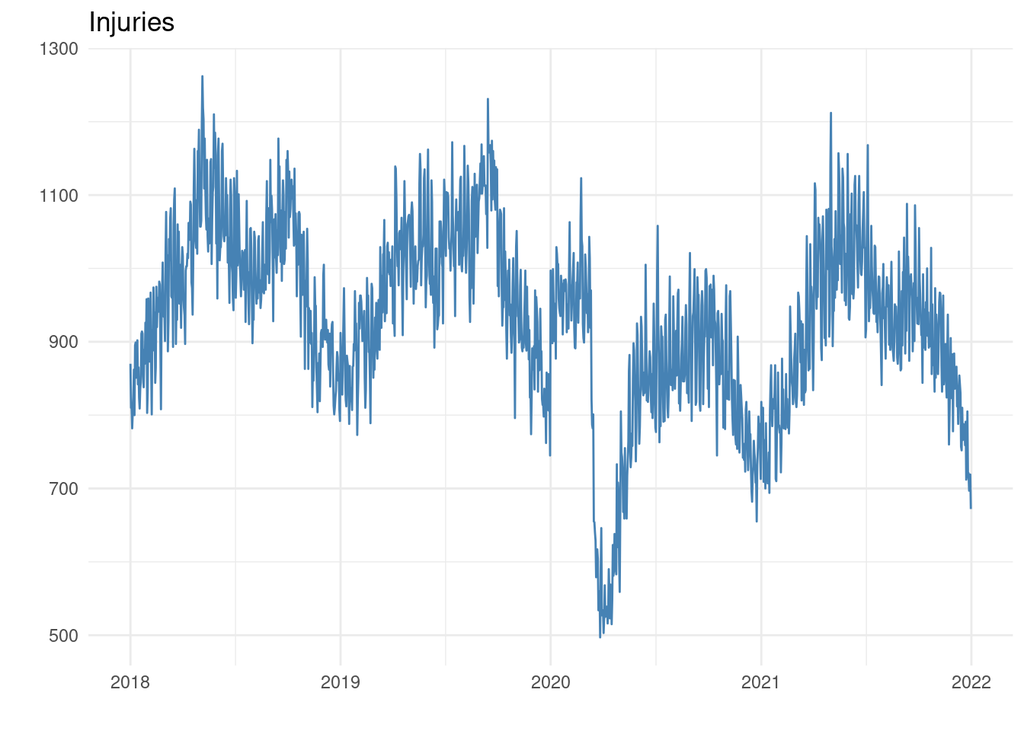

```r
df |>
  dplyr::group_by(Date) |>
  dplyr::summarise(n=n()) |>
  ggplot(aes(x=Date,y=n))+
  geom_line(color ="steelblue")+
  theme_minimal()+
  labs(x="",y="",title="Injuries")
```

Looks like 2020 was a little bit atipical comparing to the others years (Maybe the convid-19 pandemic?)

It alsos looks like it isn’t a stationary time-series, and looks like we have sort of a seasonality.

we’ll gonna back to this later when we’ll use machine learning to predict the number of injuries. By now, lets focus on analyze the the data.

Considering that each row is as injury, let’s take a look on the top 5 injuries, considering the last year, and Weight > 70

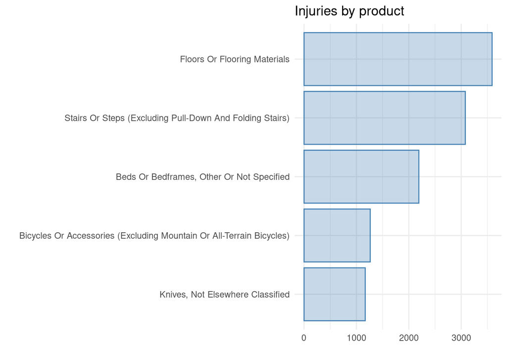

```r
df |>
  mutate(year = year(Date)) |>
  filter(year == 2021) |>
  filter(Weight >70) |>
  group_by(Product) |>
  dplyr::summarise(n=n()) |>
  arrange(desc(n)) |> head(5) |>
  ggplot(aes(x=n,y=reorder(Product,n)))+
  geom_col(color = "steelblue",fill = "steelblue", alpha = c(0.3))+
  theme_minimal()+
  labs(x="",y="",title="Injuries by product")
```

Now that we identified the top 5, lets see more deeply at the number one patterns.

Lets also see Diagnosis, Location e body_parts frequencies.

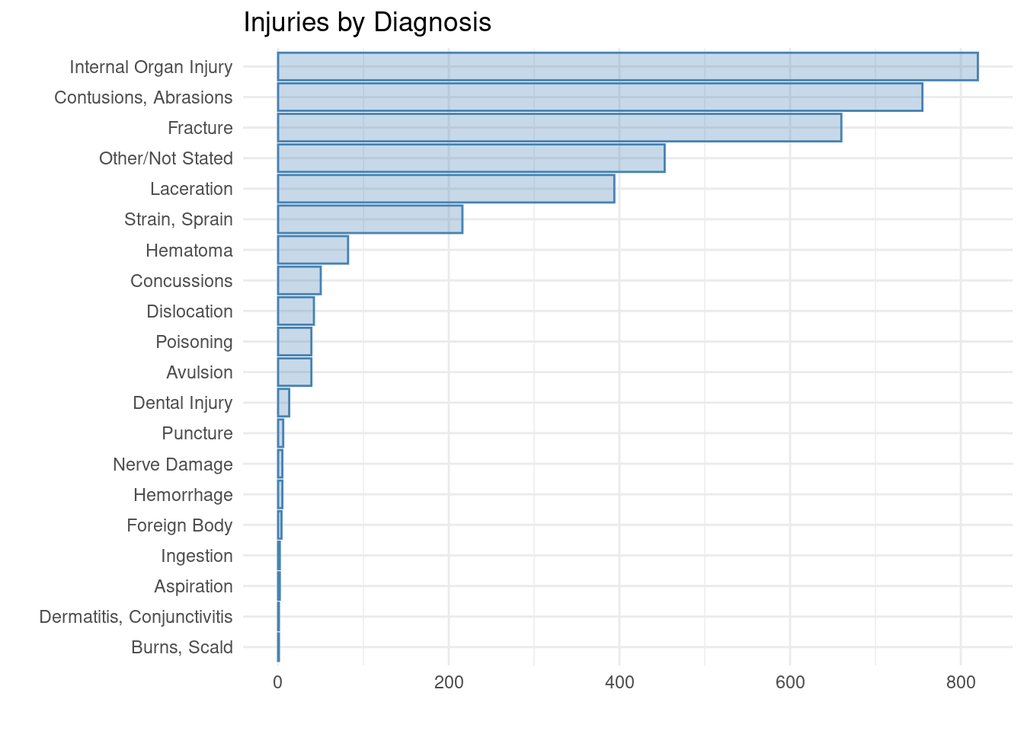

```r
df |>
  mutate(year = year(Date)) |>
  filter(year == 2021) |>
  filter(Product == "Floors Or Flooring Materials") |>
  filter(Weight >70) |>
  group_by(Diagnosis) |>
  dplyr::summarise(n=n()) |>
  arrange(desc(n)) |> head(20) |>
  ggplot(aes(x=n,y=reorder(Diagnosis,n)))+
  geom_col(color = "steelblue",fill = "steelblue", alpha = c(0.3))+
  theme_minimal()+
  labs(x="",y="",title="Injuries by Diagnosis")
```

Internal Organ injury is what more appears in the top injuries considering injuries by Floor and Flooring Materials type.

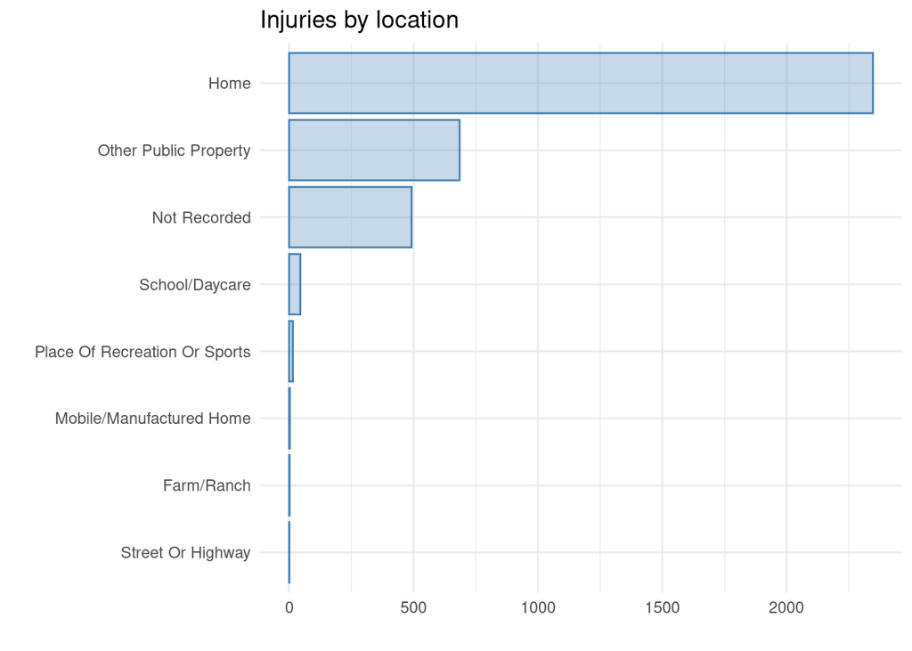

```r
df |>
  mutate(year = year(Date)) |>
  filter(year == 2021) |>
  filter(Weight >70) |>
  filter(Product == "Floors Or Flooring Materials") |>
  group_by(Location) |>
  dplyr::summarise(n=n()) |>
  arrange(desc(n)) |> head(20) |>
  ggplot(aes(x=n,y=reorder(Location,n)))+
  geom_col(color = "steelblue",fill = "steelblue", alpha = c(0.3))+
  theme_minimal()+
  labs(x="",y="",title="Injuries by location")
```

And mostly of injuries happens at home.

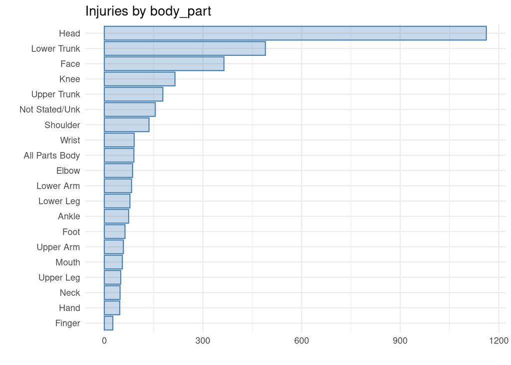

```r
df |>
  mutate(year = year(Date)) |>
  filter(year == 2021) |>
  filter(Weight >70) |>
  filter(Product == "Floors Or Flooring Materials") |>
  group_by(Body_Part) |>
  dplyr::summarise(n=n()) |>
  arrange(desc(n)) |> head(20) |>
  ggplot(aes(x=n,y=reorder(Body_Part,n)))+
  geom_col(color = "steelblue",fill = "steelblue", alpha = c(0.3))+
  theme_minimal()+
  labs(x="",y="",title="Injuries by body_part")
```

Mostly of injuries are in the Head.

Let’s take a look at a sample of narratives of those injuries.

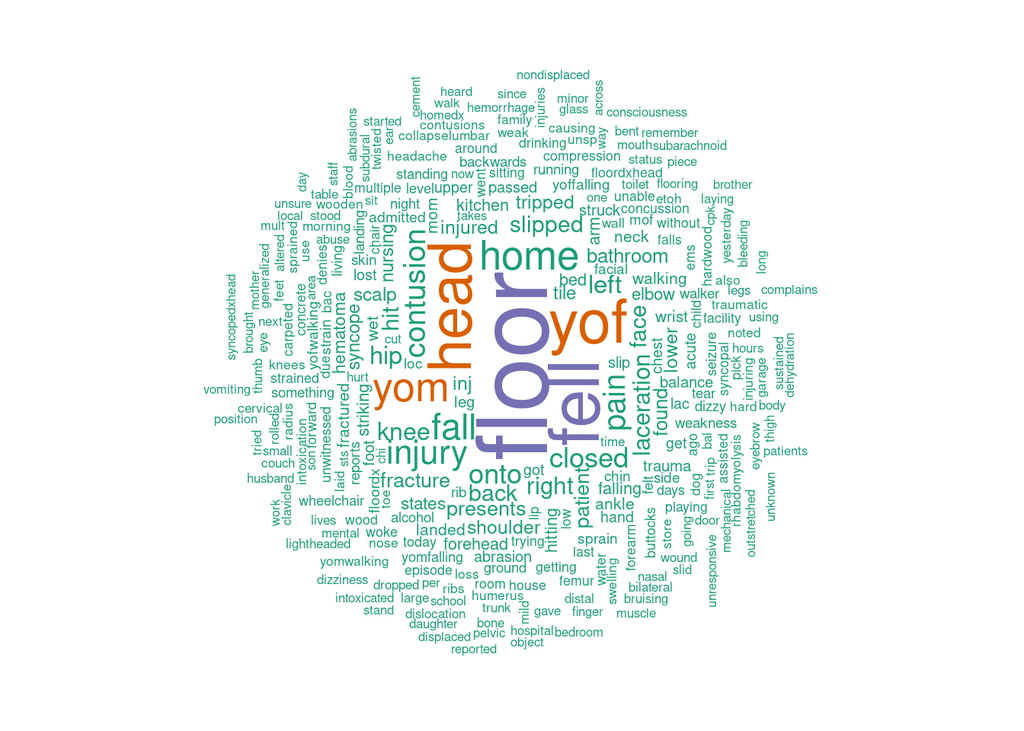

```r
# creates a word cloud
text <- df |>
  mutate(year = year(Date)) |>
  filter(year == 2021) |>
  filter(Weight >70) |>
  filter(Product == "Floors Or Flooring Materials") |>
  select(Narrative) |>
  unique() |>
  pull()

docs <- Corpus(VectorSource(text))

docs <- docs %>%
  tm_map(removeNumbers) %>%
  tm_map(removePunctuation) %>%
  tm_map(stripWhitespace)
docs <- tm_map(docs, content_transformer(tolower))
docs <- tm_map(docs, removeWords, stopwords("english"))

dtm <- TermDocumentMatrix(docs)
matrix <- as.matrix(dtm)
words <- sort(rowSums(matrix),decreasing=TRUE)
data <- data.frame(word = names(words),freq=words)

wordcloud(words = data$word, freq = data$freq, min.freq = 1,
          max.words=300, random.order=FALSE, rot.per=0.35,
          colors=brewer.pal(3, "Dark2"))
```

Now lets visualize the distribution by sex and age of people who suffered this type of injurie.

but first, we’ll gonna look the age variable if it has some incosistancy (which is very usual in this kind of variable)

```r
df |> select(Age) |> arrange(desc(Age)) |> unique()
```

```
##      Age
##   1: 223
##   2: 222
##   3: 221
##   4: 220
##   5: 219
##  ---
## 131:   5
## 132:   4
## 133:   3
## 134:   2
## 135:   0
```

Looks like the variable age has some trobles… lets desconsider age > 85

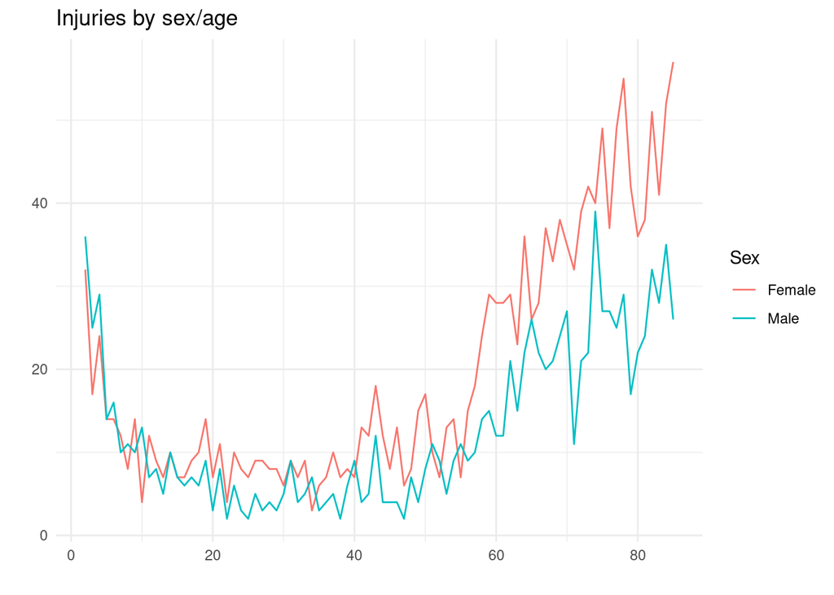

```r
df |>
  mutate(year = year(Date),
         month = month(Date)) |>
  filter(Age <= 85) |>
  filter(year == 2021) |>
  filter(Weight >70)|>
  filter(Product == "Floors Or Flooring Materials") |>
  dplyr::group_by(Age,Sex) |>
  dplyr::summarise(n=n()) |>
  ggplot(aes(x=Age,y=n))+
  geom_line(aes(color = Sex))+
  theme_minimal()+
  labs(x="",y="",title="Injuries by sex/age")
```

Thats intersting.. apparently kids and seniors suffer more injuries by floor and flooring materials. Thats tottaly makes senses,but that is a important thing to say: This dataset is about people who went to the hospital and it’s not about the populatin in general.

Another problem is: In general there are less seniors than young people. It means we’ll need to balance the dataset.

We’ll do that by creating a injurie rate per population.

In this case, I’ll use 10.000 population rate. which follows:

rate = ((n/population) * 10.000))

To do this right, lets use a population dataset of USA by age and sex

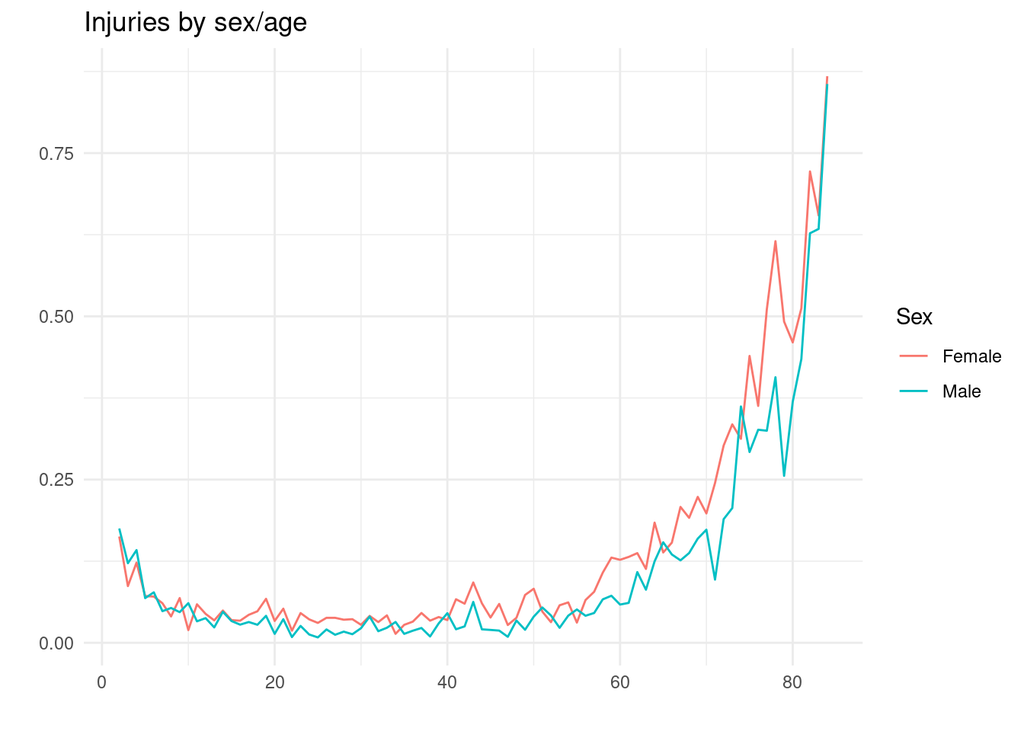

```r
# load population dataset
population <- fread("/mnt/sda1/docs/projects/neiss_analytics/data/raw/population.tsv")

# plot output
df |>
  dplyr::mutate(year = year(Date),
         month = month(Date)) |>
  dplyr::filter(Age <= 85) |>
  dplyr::filter(year == 2021) |>
  dplyr::filter(Weight >70)|>
  dplyr::filter(Product == "Floors Or Flooring Materials") |>
  dplyr::group_by(Age,Sex) |>
  dplyr::summarise(n=n()) |>
  dplyr::left_join(population |>
              dplyr::mutate_if(is.character,str_to_title) |>
              dplyr::rename(Age=age,Sex=sex),
              by = c("Sex","Age")) |>
  dplyr::mutate(rate = (n/population)*10000) |>
  na.omit() |>
  ggplot(aes(x=Age,y=rate))+
  geom_line(aes(color = Sex))+
  theme_minimal()+
  labs(x="",y="",title="Injuries by sex/age")
```

Now we have a more assertive plot. Looks like how old you get more chances you have to fall on the floor. It makes much sense. We also can see that female in general, has more chance to fall on the floor.

Let’s see this particulary age group >= 60 from the Disposition variable.

A reminder: The “Disposition” variable indicates wich treatment the pacient get.

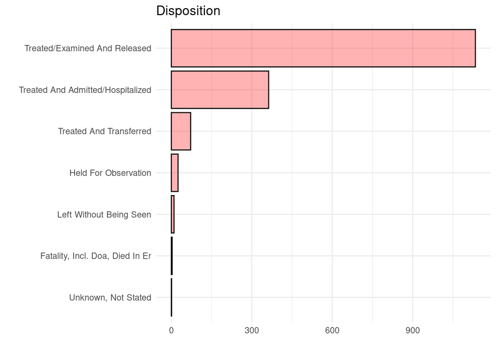

```r
df |>
  mutate(year = year(Date),
         month = month(Date)) |>
  filter(Age <= 85) |>
  filter(year == 2021) |>
  filter(Weight >70,
         Age >= 60)|>
  filter(Product == "Floors Or Flooring Materials") |>
  group_by(Disposition) |>
  dplyr::summarise(n=n()) |>
  arrange(desc(n)) |>
  ggplot(aes(x=n,y=reorder(Disposition,n)))+
  geom_col(color = "black",fill = "red", alpha = c(0.3))+
  theme_minimal()+
  labs(x="",y="",title= "Disposition")
```

In general, mostly of them was treated/Examinade and released.

We could stand and keep analysing every detail of this dataset, and it probably would take hours.

To make it more intuitive, let’s build a Shiny App in the Step 3, where we can actually see all details, collect some insights and visualize the injuries forecast for the next 12 months.

we are done for now. Next we’ll gonna build our predictive model.

#### Predictive Model

The main objective here is to predict the number of injuries for the next 12 months using the historic data,

First of all, let’s transform the dataframe to a time-series object.

```r
df.ts <- df |>
  mutate(year=as.character(year(Date)),
         month=as.character(month(Date)),
         day= as.character(day(Date))) |>
  group_by(Date,year,month,day) |>
  dplyr::summarise(n=n()) |>
  mutate(month = str_pad(month,width = 2, side="left",pad = 0)) |>
  dplyr::mutate(date_char = paste0("01/",month,"/",year)) |>
  dplyr::group_by(date_char) |>
  dplyr::summarise(n = sum(n)) |>
  mutate(date = as.Date(date_char,  format = "%d/%m/%Y"),
         month = month(date),
         year = year(date)) |>
  select(date_char,date,year,month,n)
df18 <- df.ts |> filter(year == 2018)
df19 <- df.ts |> filter(year == 2019)
df20 <- df.ts |> filter(year == 2020)
df21 <- df.ts |> filter(year == 2021)

df.ts <- rbind(df18,df19,df20,df21)

df_ts <- ts(data = df.ts |> select(n),
            start = c(2018,1),
            end = c(2021,12),
            frequency = 12)
```

And then, studying the data, wich follows:

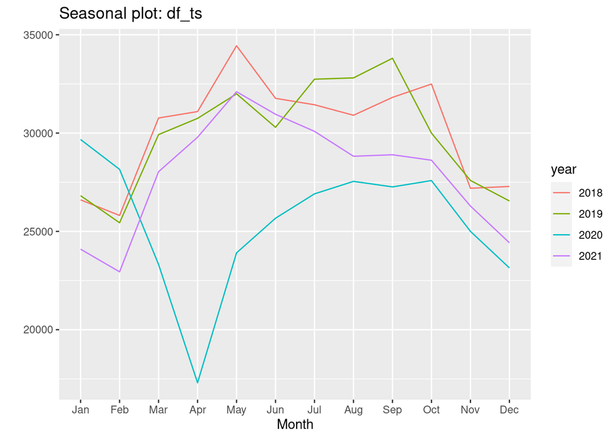

```r
ggseasonplot(df_ts)
```

The seasonal plot shows that apparently there is a trend on february and december.

We can also see a trend over march, april (except 2020 year) and may.

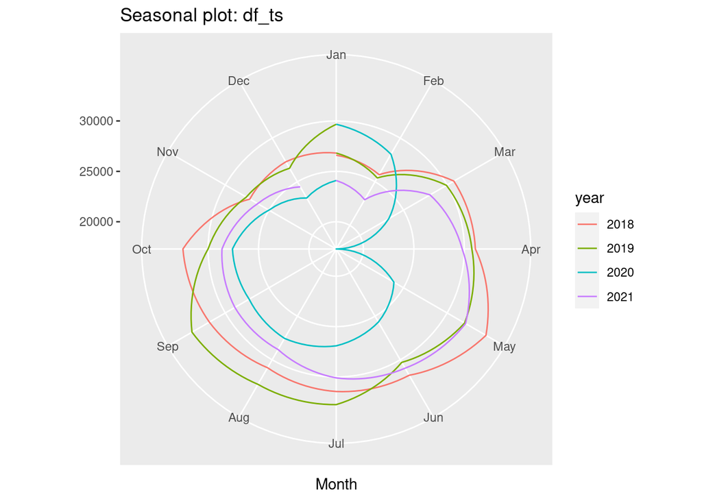

```r
ggseasonplot(df_ts, polar = TRUE)
```

Just a remminder:

**Time-Series:** Any metric that is measured over regular time intervals makes a Time Series. Example: Weather data, Stock prices, Industry forecasts, etc are some of the common ones.

**Stationary time-series:** A time series is said to be stationary if it holds the following conditions true.

1. The mean value of time-series is constant over time, which implies, the trend component is nullified. 2.The variance does not increase over time. Seasonality effect is minimal.

**Trends:** It means that a particulary time serie is on a trend (up or down) or if its stable. By analysing the trends, we can for example, make some inference if the cases numbers of a disease is gonna grow up or not.

**Seasonality:** Are periodic floatings phenomena that repeats on each period. For example, panettone sales wich grows significantly on december.

The behavior of a series can be confirmed by a mathematical model. The most common mathematical models that have a moving premise present the stationary autoregressive models — AR(p), autoregressive and moving average ARMA(p,q) and autoregressive integrated and average ARIMA(p , d,q).

The Autoregressive (AR) model — uses the target variable itself to project it from the variable in the past;

A time series follows an autoregressive process when the value of the series at time t depends on what happened at, for example, t-1, t-2, t-3, t-4, etc.

**ARMA (p,q):** Uses both an autoregressive model and a moving average model. It is Auto-regressive (AR), that is, it uses the target variable itself to project it from the variable in the past. It also presents Moving Average (MA), since it uses previous errors to make the forecast;

**ARIMA Model (p,d,q):**

Model uses both an integrated autoregressive model and a moving average model. Includes Autoregressive (AR) variable, that is, it uses the target variable itself to project it from the variable in the past. It also presents Moving Average (MA), since it uses previous errors to make the forecast;

```r
# train and test set
train <- window(df_ts,start=2018, end=2021)
test <- window(df_ts,start=2021)
```

#### Exponencial smoothing Model

```r
naive_model = naive(train,h=12)
accuracy(naive_model)
```

```
##                     ME     RMSE      MAE        MPE     MAPE      MASE
## Training set -69.66667 2691.609 2015.611 -0.8547282 7.601412 0.5965111
##                     ACF1
## Training set -0.02725264
```

We’ll use accuracy measures to compare to other models later.

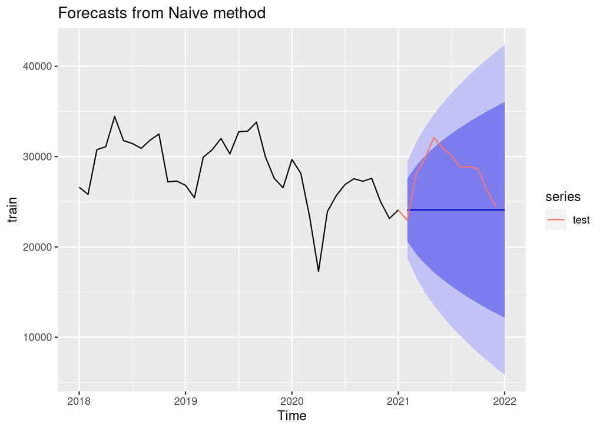

```r
autoplot(naive_model)+
  autolayer(test,series = "test")
```

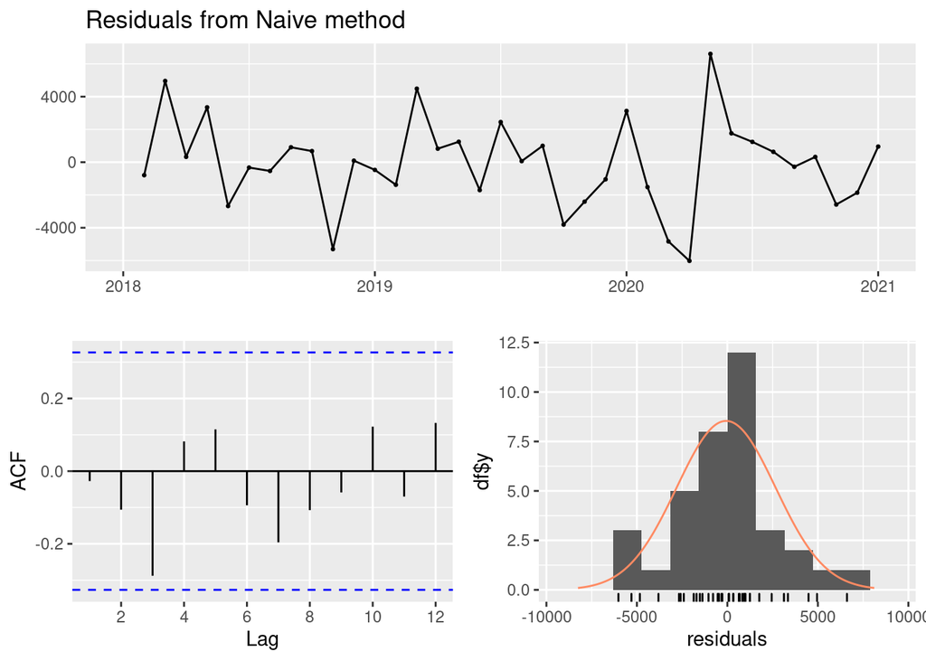

```
##
##  Ljung-Box test
##
## data:  Residuals from Naive method
## Q* = 6.9977, df = 7, p-value = 0.4291
##
## Model df: 0.   Total lags used: 7
```

```r
checkresiduals(naive_model)
```

#### Holt Model

```r
holt_model=holt(train,h=12,damped = TRUE)
accuracy(holt_model)
```

```
##                     ME     RMSE      MAE      MPE     MAPE      MASE
## Training set -208.8903 2686.952 2060.061 -1.35992 7.784961 0.6096658
##                     ACF1
## Training set 0.001466846
```

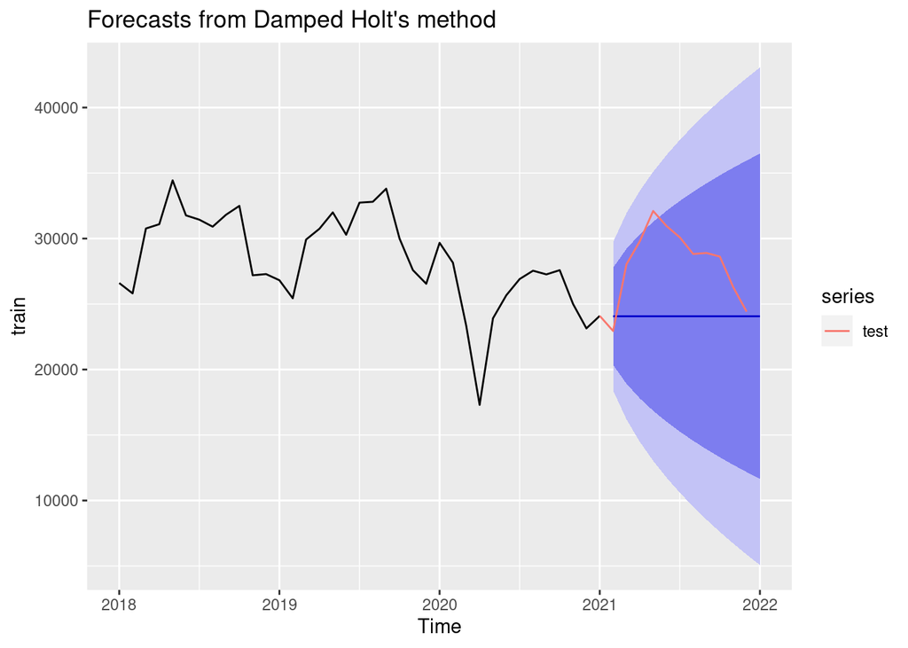

```r
autoplot(holt_model)+
  autolayer(test,series = "test")
```

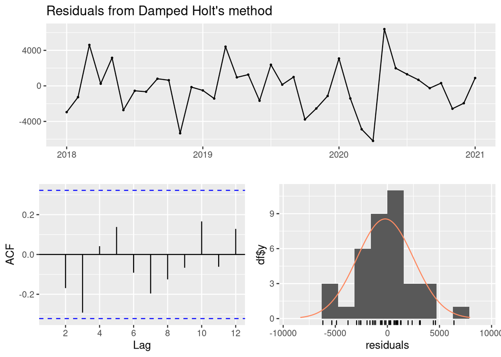

```
##
##  Ljung-Box test
##
## data:  Residuals from Damped Holt's method
## Q* = 8.7549, df = 3, p-value = 0.03273
##
## Model df: 5.   Total lags used: 8
```

```r
checkresiduals(holt_model)
```

#### Holt Winters model:

```r
hw_model=hw(train,h=12)
accuracy(hw_model)
```

```
##                     ME     RMSE      MAE        MPE     MAPE      MASE
## Training set -81.62897 2245.081 1771.207 -0.7245135 6.666367 0.5241807
##                     ACF1
## Training set 0.002146956
```

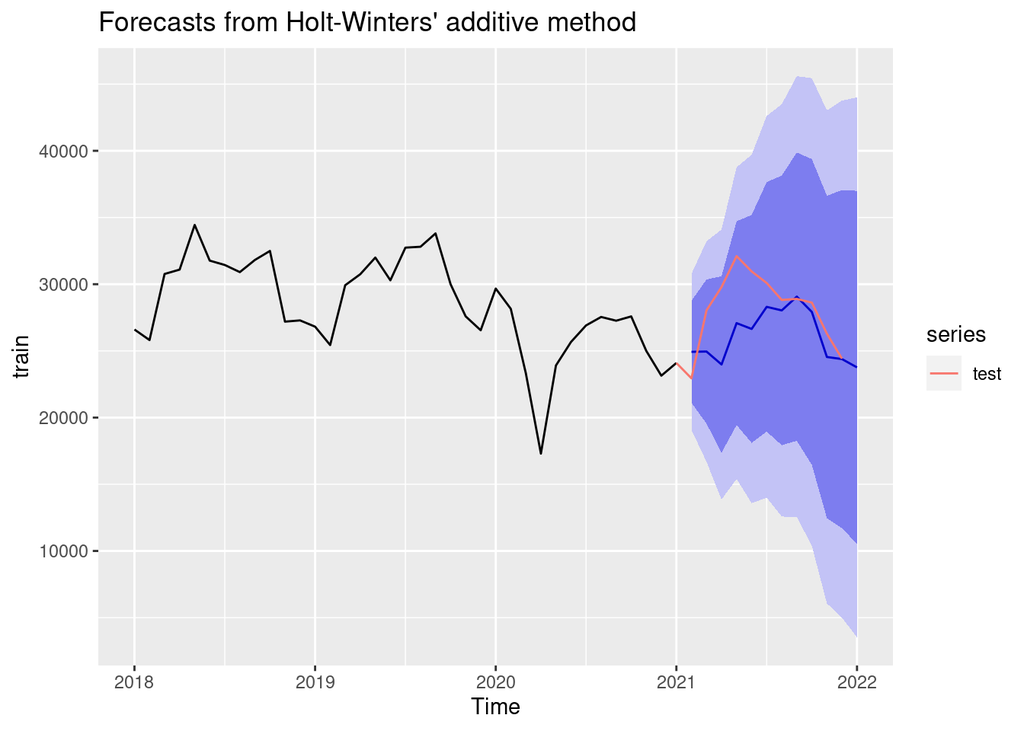

```r
autoplot(hw_model)+
  autolayer(test,series = "test")
```

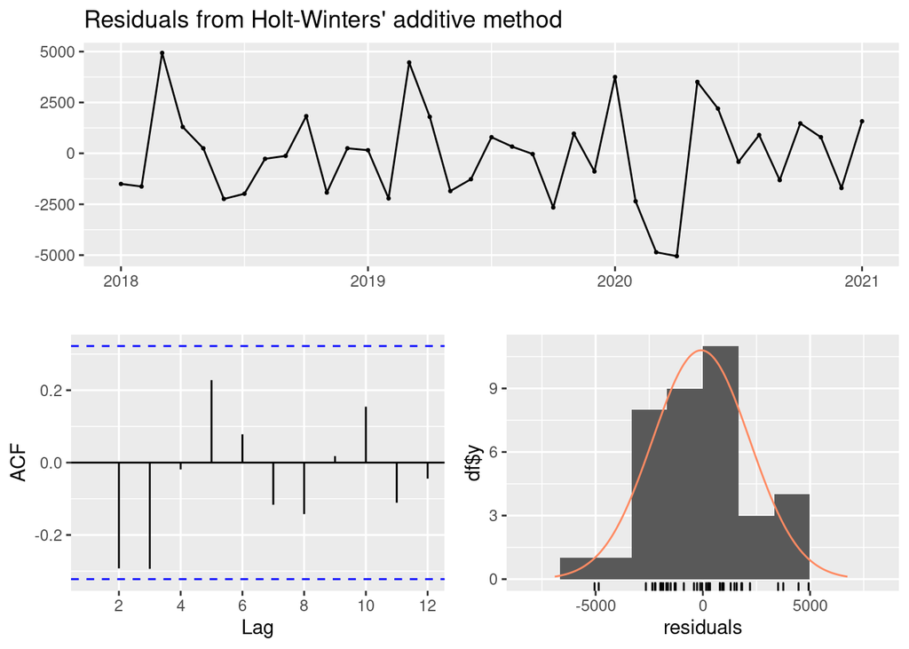

```
##
##  Ljung-Box test
##
## data:  Residuals from Holt-Winters' additive method
## Q* = 15.967, df = 3, p-value = 0.001152
##
## Model df: 16.   Total lags used: 19
```

```r
checkresiduals(hw_model)
```

#### Comparing accuracy:

Just a reminder:

**RMSE (root mean squared error):** is the measure that calculates “the root mean squared error” of errors between observed (actual) values and predictions (hypotheses).

The **mean absolute percentage error** (MAPE) — also called the mean absolute percentage deviation (MAPD) — measures accuracy of a forecast system. It measures this accuracy as a percentage, and can be calculated as the average absolute percent error for each time period minus actual values divided by actual values.

The **mean absolute percentage error (MAPE)** is the most common measure used to forecast error, probably because the variable’s units are scaled to percentage units, which makes it easier to understand [1]. It works best if there are no extremes to the data (and no zeros). It is often used as a loss function in regression analysis and model evaluation.

**Mean Absolute Scaled Error (MASE)** is a scale-free error metric that gives each error as a ratio compared to a baseline’s average error. The advantages of MASE include that it never gives undefined or infinite values and so is a good choice for intermittent-demand series (which arise when there are periods of zero demand in a forecast). It can be used on a single series, or as a tool to compare multiple series.

**Absolute Error is the amount of error in your measurements.** It is the difference between the measured value and “true” value. For example, if a scale states 90 pounds but you know your true weight is 89 pounds, then the scale has an absolute error of 90 lbs – 89 lbs = 1 lbs.

This can be caused by your scale **not measuring the exact amount you are trying to measure**. For example, your scale may be accurate to the nearest pound. If you weigh 89.6 lbs, the scale may “round up” and give you 90 lbs. In this case the absolute error is 90 lbs – 89.6 lbs = .4 lbs.

We’re looking for lowest value between those models. Lets plot them and compare.

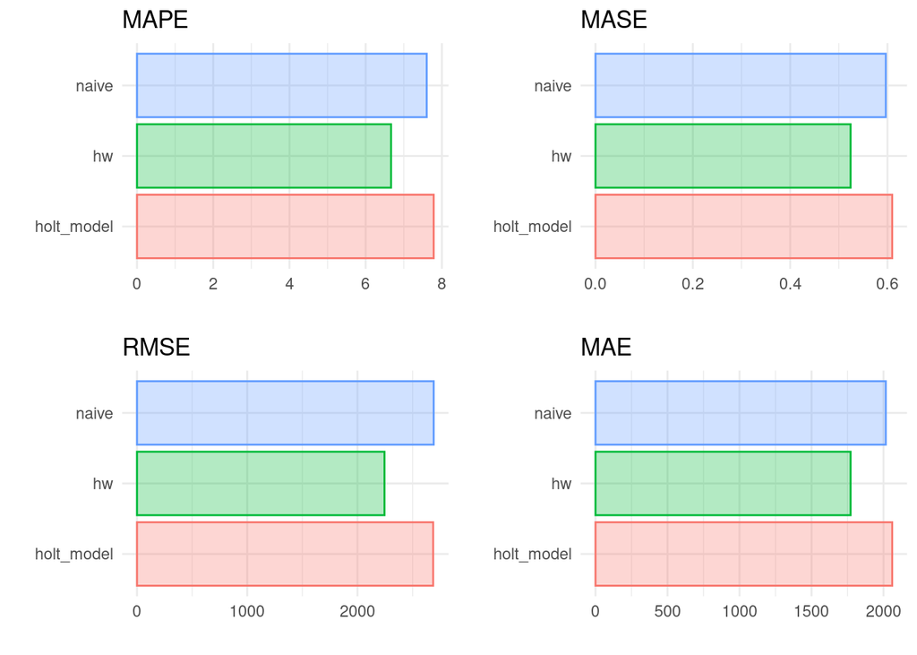

```r
df_a=as.data.frame(accuracy(holt_model))


df_a = df_a |> mutate(model = "holt_model")

df_b=as.data.frame(accuracy(hw_model))
df_b <- df_b |> mutate(model = "hw")

df_c=as.data.frame(accuracy(naive_model))

df_c=df_c |> mutate(model = "naive")

measures = rbind(df_a,df_b,df_c)

p1 <- measures |>
  ggplot(aes(x = MAPE,
             y = model))+
  geom_col(aes(color = model, fill = model), alpha = c(0.3))+
  theme_minimal()+labs(title ="MAPE",x="",y="")+
  theme(legend.position = "none")


p2 <- measures |>
  ggplot(aes(x = MASE,
             y = model))+
  geom_col(aes(color = model, fill = model), alpha = c(0.3))+
  theme_minimal()+labs(title ="MASE",x="",y="")+
  theme(legend.position = "none")



p3 <- measures |>
  ggplot(aes(x = RMSE,
             y = model))+
  geom_col(aes(color = model, fill = model), alpha = c(0.3))+
  theme_minimal()+labs(title ="RMSE",x="",y="")+
  theme(legend.position = "none")



p4 <- measures |>
  ggplot(aes(x = MAE,
             y = model))+
  geom_col(aes(color = model, fill = model), alpha = c(0.3))+
  theme_minimal()+labs(title ="MAE",x="",y="")+
  theme(legend.position = "none")


gridExtra::grid.arrange(p1,p2,p3,p4)
```

On this comparison, the best model is Holt Winters,

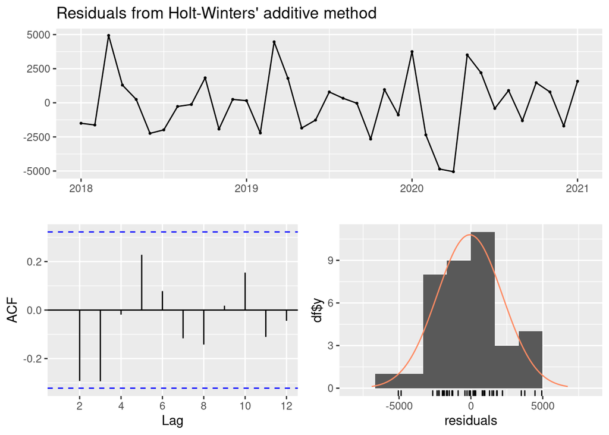

```
##
##  Ljung-Box test
##
## data:  Residuals from Holt-Winters' additive method
## Q* = 15.967, df = 3, p-value = 0.001152
##
## Model df: 16.   Total lags used: 19
```

```r
checkresiduals(hw_model)
```

About the residuals:

- The ACF plot does not show correlational significants errors.
- The residuals looks almost like a bell shape, what indicates that residuals are most freqnently at the middle.
- Unfortunately, the Ljung-Box test indicates a p-value below 0.05. It not necessary bad, but how closely p-value is from 0.05 more stable the model is. Whatever, we gonna keep this model because the others premisses looks ok.

Then lets just save the dataset and we’re done.

```r
# save the predictions dataset

hw_model <- hw(train, h=25)

predictions <- as.data.frame(hw_model)



predictions <- predictions |> mutate(date=row.names(predictions))

predictions <- predictions |> filter(grepl("2022",date)) |> select(1) |> as_tibble()
predictions <- predictions |>
  mutate(date = c("01/01/2022",
                  "01/02/2022",
                  "01/03/2022",
                  "01/04/2022",
                  "01/05/2022",
                  "01/06/2022",
                  "01/07/2022",
                  "01/08/2022",
                  "01/09/2022",
                  "01/10/2022",
                  "01/11/2022",
                  "01/12/2022")) |>
  select(date,1) |>
  dplyr::rename(forecast=`Point Forecast`) |>
  as_tibble()


df.ts2 <- rbind(df.ts |>
                  select(date,n) |>
                  dplyr::rename(forecast = n),
                predictions |>
                  mutate(date = as.Date(date, format = "%d/%m/%Y"))) |>
  mutate(type = ifelse(year(date) == "2022","forecast","real"))


df.ts2 <- df.ts2 |> mutate(forecast=round(forecast))


write.csv2(df.ts2,
           "/mnt/sda1/docs/projects/neiss_analytics/data/processed/forecast.csv",
           row.names=FALSE)
```